# U.S.-based Regional Airline Pilot Retention Analysis

General Factor Rankings and Subfactor Priorities (n=57)

Authors

Affiliations

Michael J. Hickey

University of North Dakota

Marina Efthymiou

Dublin City University

James Higgins

University of North Dakota

Aman Gupta

Embry-Riddle Aeronautical University

Robert Walton

Embry-Riddle Aeronautical University

Published

January 7, 2026

# 1 Overview

**Repository:** [GitHub](https://github.com/mikehickey2/US-Airline-Pilot-Retention-Analysis)

This analysis examines pilot retention priorities from a survey of U.S.-based regional airline pilots (n = 57).

The analysis has two parts:

1. **General Retention Factors** - Rankings of six broad retention constructs and demographic comparisons
2. **Subfactor Analysis** - Within-construct priorities for 31 specific retention elements

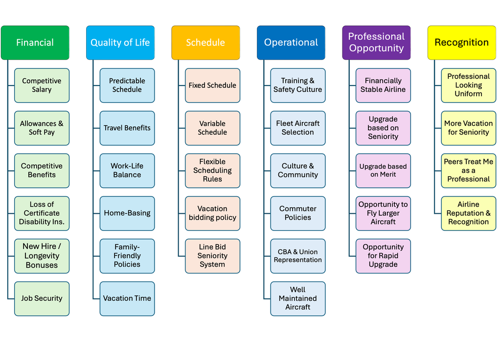

Figure 1: Factors of Pilot Retention in U.S.-based Regional Airlines

# 2 Statistical Methods

## 2.1 Sample and Data Collection

Survey data was collected from U.S.-based regional airline pilots during April and May 2025. After exclusions for incomplete responses and non-regional airline pilots, n = 57 valid responses remained for analysis.

## 2.2 Statistical Tests

All ranking data is ordinal; therefore, non-parametric tests are used throughout:

- **Friedman Test**: Within-subjects comparison of factor rankings
- **Mann-Whitney U**: Between-groups comparison for binary demographics
- **Kruskal-Wallis H**: Between-groups comparison for multi-level demographics

## 2.3 Multiple Testing Correction

This quantitative study employs a **hierarchical false discovery rate (FDR) control procedure**:

**General Factor Analysis (24 tests):** Benjamini-Hochberg FDR at q = 0.10 applied across all demographic comparisons (6 factors x 4 demographics).

**Subfactor Analysis (155 tests):** Two-step hierarchical procedure:

1. **Screening**: For each construct, compute minimum p-value across demographics. Apply BH-FDR at q = 0.10 to these 6 screening p-values.
2. **Within-construct testing**: For constructs passing screening, apply Holm’s procedure at alpha = 0.05 to demographic comparisons.

**Rationale**: Standard Bonferroni correction (alpha/155 = 0.0003) is overly conservative for exploratory research, causing 50-70% Type II error rates. FDR control at q = 0.10 balances discovery against false positives appropriately for hypothesis generation.

## 2.5 Software

Analysis conducted in Positron (Version: 2025.12.2 build 5) with R 4.5.2 using: tidyverse, rstatix, coin, DescTools, knitr, janitor.

**Code Availability:** The complete analysis code is available at `scripts/analysis/unified_retention_analysis-mod57.qmd` in the [GitHub repository](https://github.com/mikehickey2/US-Airline-Pilot-Retention-Analysis).

# 3 Setup

# 4 Data Loading and Preprocessing

Data Exclusion Summary

| exclusion_reason | n |
| --- | --- |
| did_not_finish | 35 |
| included | 76 |
| not_air_carrier | 2 |

**NoteSample**

This analysis includes **U.S.-based regional airline pilots** (n = 57).

Table 1: Sample Demographic Summary

| Demographic | Category | n |
| --- | --- | --- |
| Age Group | ≤ 35 years | 47 |
|  | > 35 years | 10 |
| Experience | Q1 (least) | 15 |
|  | Q2 | 14 |
|  | Q3 | 14 |
|  | Q4 (most) | 14 |
| Gender | Male | 51 |
|  | Female | 5 |
|  | Other/NA | 1 |
| Military Background | Yes | 4 |
|  | No | 53 |
| Position | Captain | 21 |
|  | First Officer | 36 |
| Carrier Type | Regional | 57 |
|  | Major | 0 |
|  | LCC | 0 |
|  | Other | 0 |

**Final sample:** 57 pilots included in analysis.

# 5 Part 1: General Retention Factor Analysis

This section analyzes the rankings of six broad retention constructs:

1. Financial (salary, benefits, bonuses)
2. Quality of Life (schedule, family, work-life balance)
3. Professional Opportunity (stability, upgrade, aircraft type)
4. Recognition (uniform, respect, awards)
5. Schedule (fixed vs variable, bidding systems)
6. Operational (SOPs, training, equipment, pilot skill)

## 5.1 Descriptive Statistics

Table 1: Rank Summary for General Retention Factors

| factor | n | median | iqr | mean | sd |
| --- | --- | --- | --- | --- | --- |
| financial | 57 | 2 | 2 | 2.23 | 1.17 |
| qol | 57 | 2 | 2 | 2.07 | 1.21 |
| schedule | 57 | 2 | 1 | 2.39 | 0.92 |
| operational | 57 | 4 | 1 | 4.44 | 1.12 |
| professional | 57 | 5 | 1 | 4.39 | 1.16 |
| recognition | 57 | 6 | 1 | 5.49 | 0.91 |

Distribution of top-ranked retention factors among regional airline pilots

Table 2: Number (and %) of Pilots Ranking Each Factor #1

| factor | n | percent |
| --- | --- | --- |
| qol | 25 | 43.9 |
| financial | 20 | 35.1 |
| schedule | 9 | 15.8 |
| professional | 2 | 3.5 |
| operational | 1 | 1.8 |

Distribution of top-ranked retention factors among regional airline pilots

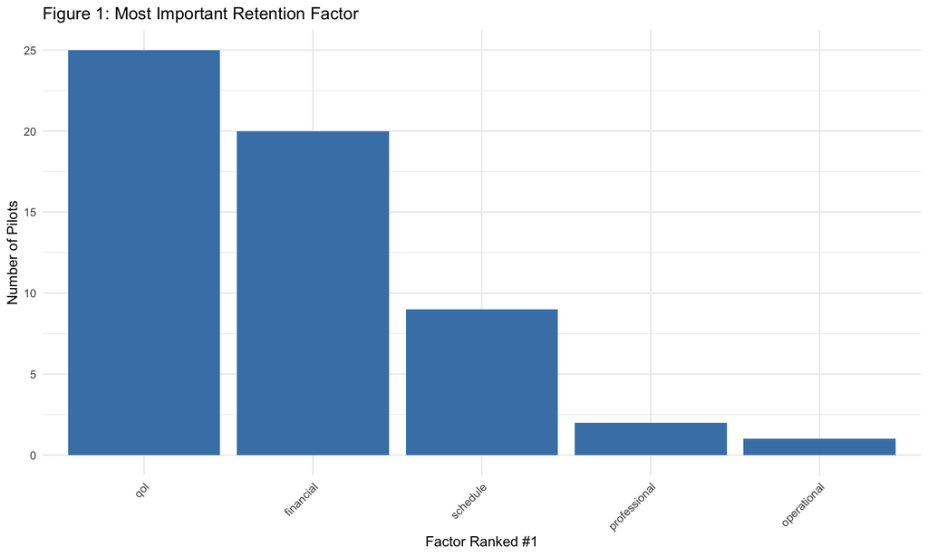

Distribution of top-ranked retention factors among regional airline pilots

## 5.2 Friedman Test: Overall Factor Rankings

Friedman Test: Overall Difference in Factor Rankings

| .y. | n | statistic | df | p | method |
| --- | --- | --- | --- | --- | --- |
| rank | 57 | 171.556 | 5 | 0 | Friedman test |

Table 3: Pairwise Wilcoxon Tests Between General Factors (Holm-adjusted)

| comparison | statistic | p | p.adj | sig |
| --- | --- | --- | --- | --- |
| financial vs operational | 133.5 | 0.000 | 0.0000 | * |
| financial vs professional | 104.5 | 0.000 | 0.0000 | * |
| financial vs qol | 916.5 | 0.468 | 0.9480 |  |
| financial vs recognition | 8.5 | 0.000 | 0.0000 | * |
| financial vs schedule | 704.0 | 0.316 | 0.9480 |  |
| operational vs professional | 826.0 | 1.000 | 1.0000 |  |
| operational vs qol | 1600.0 | 0.000 | 0.0000 | * |
| operational vs recognition | 311.5 | 0.000 | 0.0002 | * |
| operational vs schedule | 1565.0 | 0.000 | 0.0000 | * |
| professional vs qol | 1547.5 | 0.000 | 0.0000 | * |
| professional vs recognition | 288.5 | 0.000 | 0.0001 | * |
| professional vs schedule | 1545.0 | 0.000 | 0.0000 | * |
| qol vs recognition | 36.0 | 0.000 | 0.0000 | * |
| qol vs schedule | 649.5 | 0.148 | 0.5920 |  |
| recognition vs schedule | 1641.5 | 0.000 | 0.0000 | * |

## 5.3 Demographic Comparisons

### 5.3.1 Age Groups (≤35 vs >35)

Table 4: Mann-Whitney U Tests - Age Groups (≤35 vs >35)

| factor | > 35_n | ≤ 35_n | > 35_median | ≤ 35_median | statistic | p_raw | p_adj_fdr | sig_fdr10 | n1 | n2 |
| --- | --- | --- | --- | --- | --- | --- | --- | --- | --- | --- |
| qol | 10 | 47 | 3.0 | 1 | 361.0 | 0.005 | 0.032 | * | 10 | 47 |
| schedule | 10 | 47 | 1.5 | 2 | 163.5 | 0.114 | 0.290 |  | 10 | 47 |
| recognition | 10 | 47 | 5.5 | 6 | 177.5 | 0.145 | 0.290 |  | 10 | 47 |
| financial | 10 | 47 | 2.0 | 2 | 227.5 | 0.878 | 0.974 |  | 10 | 47 |
| operational | 10 | 47 | 4.5 | 4 | 233.0 | 0.974 | 0.974 |  | 10 | 47 |
| professional | 10 | 47 | 4.5 | 5 | 233.0 | 0.974 | 0.974 |  | 10 | 47 |

### 5.3.2 Experience Quartiles

Table 5: Median Rank of General Factors by Experience Quartile

| factor | Q1 (least)_n | Q2_n | Q3_n | Q4 (most)_n | Q1 (least)_median | Q2_median | Q3_median | Q4 (most)_median |
| --- | --- | --- | --- | --- | --- | --- | --- | --- |
| financial | 15 | 14 | 14 | 14 | 3 | 1.5 | 1 | 2.5 |
| operational | 15 | 14 | 14 | 14 | 4 | 5.0 | 4 | 4.0 |
| professional | 15 | 14 | 14 | 14 | 4 | 4.5 | 5 | 5.0 |
| qol | 15 | 14 | 14 | 14 | 1 | 2.0 | 2 | 2.0 |
| recognition | 15 | 14 | 14 | 14 | 6 | 6.0 | 6 | 5.5 |
| schedule | 15 | 14 | 14 | 14 | 2 | 3.0 | 2 | 2.0 |

Table 6: Kruskal-Wallis Tests for Experience Quartiles (FDR-adjusted)

| factor | statistic | df | p_raw | p_adj_fdr | sig_fdr10 |
| --- | --- | --- | --- | --- | --- |
| financial | 8.769 | 3 | 0.032 | 0.195 |  |
| operational | 2.673 | 3 | 0.445 | 0.534 |  |
| professional | 1.675 | 3 | 0.643 | 0.643 |  |
| qol | 5.321 | 3 | 0.150 | 0.300 |  |
| recognition | 3.777 | 3 | 0.287 | 0.430 |  |
| schedule | 5.373 | 3 | 0.146 | 0.300 |  |

### 5.3.3 Gender (Male vs Female)

Table 7: Median Rank of General Factors by Gender

| factor | Female_n | Male_n | Female_median | Male_median |
| --- | --- | --- | --- | --- |
| financial | 5 | 51 | 3 | 2 |
| operational | 5 | 51 | 4 | 5 |
| professional | 5 | 51 | 5 | 5 |
| qol | 5 | 51 | 1 | 2 |
| recognition | 5 | 51 | 6 | 6 |
| schedule | 5 | 51 | 2 | 2 |

Table 8: Mann-Whitney U Tests - Male vs Female (Exact test, FDR-adjusted)

| factor | statistic | p_raw | p_adj_fdr | sig_fdr10 | n1 | n2 |
| --- | --- | --- | --- | --- | --- | --- |
| financial | 190.0 | 0.063 | 0.190 |  | 5 | 51 |
| operational | 86.0 | 0.220 | 0.330 |  | 5 | 51 |
| professional | 155.5 | 0.406 | 0.487 |  | 5 | 51 |
| qol | 47.5 | 0.016 | 0.096 | * | 5 | 51 |
| recognition | 172.5 | 0.121 | 0.242 |  | 5 | 51 |
| schedule | 110.5 | 0.616 | 0.616 |  | 5 | 51 |

**Note**

**Note on Gender Comparisons:** With only 5 female respondents in this regional subset, statistical power for detecting gender differences is severely limited. Results should be interpreted with extreme caution.

### 5.3.4 Military Background

Table 9: Median Rank of General Factors by Military Background

| factor | No_n | Yes_n | No_median | Yes_median |
| --- | --- | --- | --- | --- |
| financial | 53 | 4 | 2 | 2.5 |
| operational | 53 | 4 | 4 | 5.0 |
| professional | 53 | 4 | 5 | 4.0 |
| qol | 53 | 4 | 2 | 2.0 |
| recognition | 53 | 4 | 6 | 6.0 |
| schedule | 53 | 4 | 2 | 1.0 |

### 5.3.5 Flight-Deck Position (Captain vs First Officer)

Table 11: Median Rank of General Factors by Flight-Deck Position

| factor | Captain_n | First Officer_n | Captain_median | First Officer_median |
| --- | --- | --- | --- | --- |
| financial | 21 | 36 | 2 | 2 |
| operational | 21 | 36 | 5 | 4 |
| professional | 21 | 36 | 4 | 5 |
| qol | 21 | 36 | 2 | 2 |
| recognition | 21 | 36 | 6 | 6 |
| schedule | 21 | 36 | 2 | 2 |

Table 12: Mann-Whitney U Tests - Captain vs First Officer (FDR-adjusted)

| factor | statistic | p_raw | p_adj_fdr | sig_fdr10 | n1 | n2 |
| --- | --- | --- | --- | --- | --- | --- |
| financial | 310.5 | 0.248 | 0.560 |  | 21 | 36 |
| operational | 497.5 | 0.040 | 0.240 |  | 21 | 36 |
| professional | 334.5 | 0.453 | 0.655 |  | 21 | 36 |
| qol | 413.0 | 0.546 | 0.655 |  | 21 | 36 |
| recognition | 324.0 | 0.280 | 0.560 |  | 21 | 36 |
| schedule | 378.0 | 1.000 | 1.000 |  | 21 | 36 |

### 5.3.6 Carrier Type

**NoteNot Applicable**

Carrier type comparison is not applicable as all 57 pilots in this sample are employed at U.S.-based regional airlines.

## 5.4 Summary: General Factor Results

Summary: General Factor Demographic Comparisons (BH-FDR at q=0.10)

| Demographic | Tests | Min_p_raw | Min_p_adj | Significant_q10 |
| --- | --- | --- | --- | --- |
| Age (<=35 vs >35) | 6 | 0.0054 | 0.0322 | 1 |
| Experience Quartiles | 6 | 0.0325 | 0.1950 | 0 |
| Gender (Male vs Female) | 6 | 0.0160 | 0.0960 | 1 |
| Military | 0 | NA | NA | NA |
| Flight-Deck Position | 6 | 0.0400 | 0.2400 | 0 |

**General Factor Analysis Summary:**

- Total demographic comparisons: 24
- Significant at FDR q=0.10: 2
- Discovery rate: 8.3%

# 6 Part 2: Subfactor Analysis

This section examines the 31 subfactors within each retention construct and tests for demographic differences in within-construct priorities.

## 6.1 Financial Subfactors

Financial Subfactors - Descriptive Statistics

| item | n | median | mean | sd | pct_rank1 |
| --- | --- | --- | --- | --- | --- |
| Competitive salary | 57 | 2 | 1.77 | 0.78 | 38.60 |
| Allowances and soft pay | 57 | 4 | 3.88 | 1.28 | 1.75 |
| Benefits package | 57 | 3 | 3.46 | 1.21 | 5.26 |
| Disability insurance | 57 | 5 | 4.54 | 1.07 | 1.75 |
| Job security | 57 | 1 | 1.96 | 1.27 | 52.63 |
| New hire/longevity bonuses | 57 | 6 | 5.39 | 1.01 | 0.00 |

Median ranks for Financial subfactors

Financial: Friedman Test

| .y. | n | statistic | df | p | method |
| --- | --- | --- | --- | --- | --- |
| rank | 57 | 165.03 | 5 | 0 | Friedman test |

Median ranks for Financial subfactors

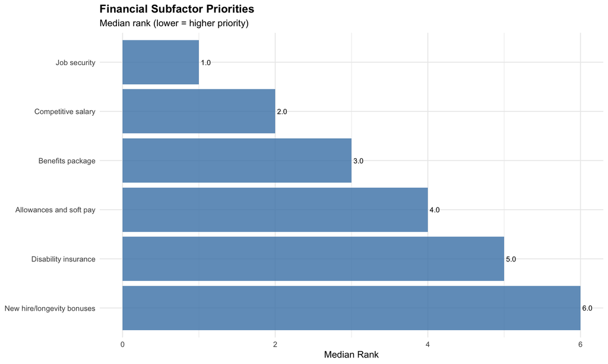

Median ranks for Financial subfactors

Financial: Age Group Comparisons

| item | statistic | p | p_adj_holm | p.adj.signif | effsize | magnitude |
| --- | --- | --- | --- | --- | --- | --- |
| Competitive salary | 229.0 | 0.898 | 1.000 | ns | 0.019 | small |
| Allowances and soft pay | 170.0 | 0.164 | 0.984 | ns | 0.186 | small |
| Benefits package | 298.5 | 0.174 | 0.984 | ns | 0.182 | small |
| Disability insurance | 272.0 | 0.422 | 1.000 | ns | 0.108 | small |
| Job security | 200.0 | 0.429 | 1.000 | ns | 0.106 | small |
| New hire/longevity bonuses | 271.0 | 0.380 | 1.000 | ns | 0.118 | small |

Median ranks for Financial subfactors

Financial: Gender Comparisons

| item | statistic | p | p_adj_holm | p.adj.signif | effsize | magnitude |
| --- | --- | --- | --- | --- | --- | --- |
| Competitive salary | 206.0 | 0.012 | 0.073 | ns | 0.337 | moderate |
| Allowances and soft pay | 176.0 | 0.155 | 0.620 | ns | 0.192 | small |
| Benefits package | 90.0 | 0.273 | 0.620 | ns | 0.148 | small |
| Disability insurance | 81.5 | 0.171 | 0.620 | ns | 0.185 | small |
| Job security | 62.5 | 0.042 | 0.210 | ns | 0.274 | small |
| New hire/longevity bonuses | 151.5 | 0.421 | 0.620 | ns | 0.110 | small |

Median ranks for Financial subfactors

Financial: Position Comparisons

| item | statistic | p | p_adj_holm | p.adj.signif | effsize | magnitude |
| --- | --- | --- | --- | --- | --- | --- |
| Competitive salary | 332.5 | 0.408 | 1.000 | ns | 0.111 | small |
| Allowances and soft pay | 352.5 | 0.670 | 1.000 | ns | 0.057 | small |
| Benefits package | 375.5 | 0.973 | 1.000 | ns | 0.006 | small |
| Disability insurance | 412.5 | 0.555 | 1.000 | ns | 0.079 | small |
| Job security | 375.5 | 0.971 | 1.000 | ns | 0.006 | small |
| New hire/longevity bonuses | 471.5 | 0.070 | 0.418 | ns | 0.242 | small |

Median ranks for Financial subfactors

Financial: Military Comparisons

| item | statistic | p | p_adj_holm | p.adj.signif | effsize | magnitude |
| --- | --- | --- | --- | --- | --- | --- |
| Competitive salary | 150.5 | 0.127 | 0.762 | ns | 0.204 | small |
| Allowances and soft pay | 108.0 | 0.962 | 1.000 | ns | 0.009 | small |
| Benefits package | 104.0 | 0.962 | 1.000 | ns | 0.009 | small |
| Disability insurance | 94.5 | 0.719 | 1.000 | ns | 0.050 | small |
| Job security | 68.5 | 0.207 | 1.000 | ns | 0.169 | small |
| New hire/longevity bonuses | 121.5 | 0.581 | 1.000 | ns | 0.076 | small |

Median ranks for Financial subfactors

Financial: Experience Comparisons

| item | statistic | df | p | p_adj_holm | p.adj.signif | effsize | magnitude |
| --- | --- | --- | --- | --- | --- | --- | --- |
| Competitive salary | 1.055 | 3 | 0.788 | 1 | ns | -0.037 | small |
| Allowances and soft pay | 3.801 | 3 | 0.284 | 1 | ns | 0.015 | small |
| Benefits package | 0.471 | 3 | 0.925 | 1 | ns | -0.048 | small |
| Disability insurance | 0.923 | 3 | 0.820 | 1 | ns | -0.039 | small |
| Job security | 0.749 | 3 | 0.862 | 1 | ns | -0.042 | small |
| New hire/longevity bonuses | 1.940 | 3 | 0.585 | 1 | ns | -0.020 | small |

Median ranks for Financial subfactors

## 6.2 Quality of Life Subfactors

Quality of Life Subfactors - Descriptive Statistics

| item | n | median | mean | sd | pct_rank1 |
| --- | --- | --- | --- | --- | --- |
| Predictable schedule | 57 | 3 | 2.68 | 1.17 | 15.79 |
| Vacation time | 57 | 4 | 4.23 | 1.18 | 1.75 |
| Family-friendly policies | 57 | 5 | 4.60 | 1.31 | 1.75 |
| Possibility of being based at home | 57 | 2 | 2.35 | 1.66 | 43.86 |
| Travel benefits | 57 | 5 | 4.81 | 1.26 | 1.75 |
| Work-life balance | 57 | 2 | 2.33 | 1.44 | 35.09 |

Median ranks for Quality of Life subfactors

Quality of Life: Friedman Test

| .y. | n | statistic | df | p | method |
| --- | --- | --- | --- | --- | --- |
| rank | 57 | 110.544 | 5 | 0 | Friedman test |

Median ranks for Quality of Life subfactors

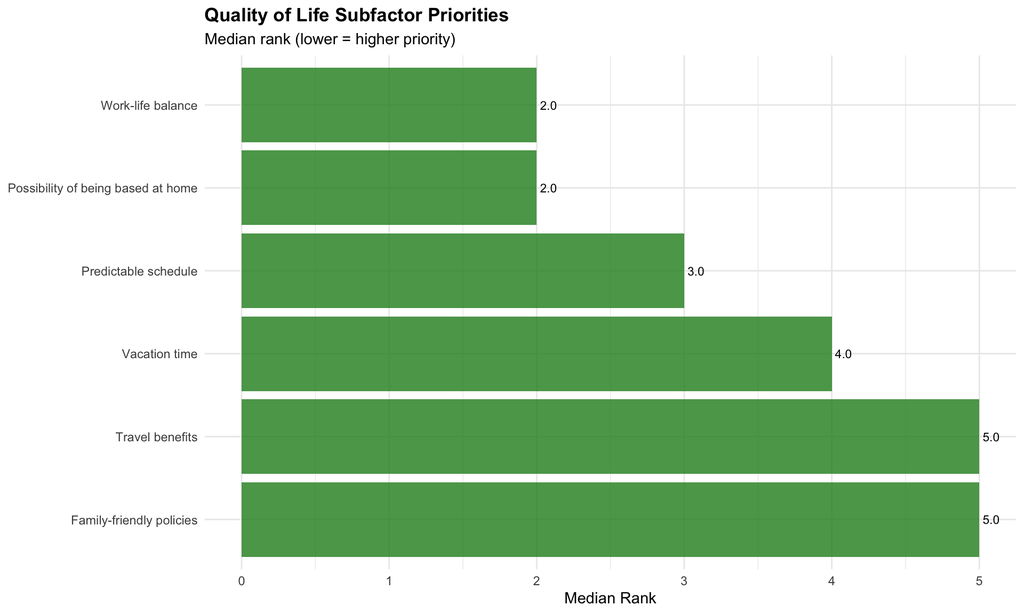

Median ranks for Quality of Life subfactors

Quality of Life: Age Group Comparisons

| item | statistic | p | p_adj_holm | p.adj.signif | effsize | magnitude |
| --- | --- | --- | --- | --- | --- | --- |
| Predictable schedule | 178.0 | 0.219 | 1 | ns | 0.164 | small |
| Vacation time | 240.0 | 0.921 | 1 | ns | 0.015 | small |
| Family-friendly policies | 206.5 | 0.544 | 1 | ns | 0.082 | small |
| Possibility of being based at home | 230.0 | 0.921 | 1 | ns | 0.015 | small |
| Travel benefits | 242.5 | 0.878 | 1 | ns | 0.022 | small |
| Work-life balance | 291.0 | 0.225 | 1 | ns | 0.162 | small |

Median ranks for Quality of Life subfactors

Quality of Life: Gender Comparisons

| item | statistic | p | p_adj_holm | p.adj.signif | effsize | magnitude |
| --- | --- | --- | --- | --- | --- | --- |
| Predictable schedule | 97.0 | 0.372 | 1 | ns | 0.121 | small |
| Vacation time | 132.0 | 0.904 | 1 | ns | 0.018 | small |
| Family-friendly policies | 121.5 | 0.870 | 1 | ns | 0.024 | small |
| Possibility of being based at home | 121.0 | 0.856 | 1 | ns | 0.026 | small |
| Travel benefits | 165.5 | 0.260 | 1 | ns | 0.152 | small |
| Work-life balance | 124.5 | 0.940 | 1 | ns | 0.012 | small |

Median ranks for Quality of Life subfactors

Quality of Life: Position Comparisons

| item | statistic | p | p_adj_holm | p.adj.signif | effsize | magnitude |
| --- | --- | --- | --- | --- | --- | --- |
| Predictable schedule | 436.5 | 0.320 | 1 | ns | 0.133 | small |
| Vacation time | 360.5 | 0.768 | 1 | ns | 0.040 | small |
| Family-friendly policies | 368.5 | 0.878 | 1 | ns | 0.022 | small |
| Possibility of being based at home | 347.5 | 0.601 | 1 | ns | 0.070 | small |
| Travel benefits | 316.5 | 0.291 | 1 | ns | 0.141 | small |
| Work-life balance | 400.0 | 0.711 | 1 | ns | 0.050 | small |

Median ranks for Quality of Life subfactors

Quality of Life: Military Comparisons

| item | statistic | p | p_adj_holm | p.adj.signif | effsize | magnitude |
| --- | --- | --- | --- | --- | --- | --- |
| Predictable schedule | 77.0 | 0.356 | 1.000 | ns | 0.124 | small |
| Vacation time | 116.0 | 0.756 | 1.000 | ns | 0.043 | small |
| Family-friendly policies | 98.0 | 0.809 | 1.000 | ns | 0.034 | small |
| Possibility of being based at home | 151.0 | 0.143 | 0.858 | ns | 0.196 | small |
| Travel benefits | 95.5 | 0.744 | 1.000 | ns | 0.045 | small |
| Work-life balance | 99.5 | 0.845 | 1.000 | ns | 0.028 | small |

Median ranks for Quality of Life subfactors

Quality of Life: Experience Comparisons

| item | statistic | df | p | p_adj_holm | p.adj.signif | effsize | magnitude |
| --- | --- | --- | --- | --- | --- | --- | --- |
| Predictable schedule | 9.404 | 3 | 0.024 | 0.146 | ns | 0.121 | moderate |
| Vacation time | 6.544 | 3 | 0.088 | 0.352 | ns | 0.067 | moderate |
| Family-friendly policies | 1.304 | 3 | 0.728 | 1.000 | ns | -0.032 | small |
| Possibility of being based at home | 7.375 | 3 | 0.061 | 0.304 | ns | 0.083 | moderate |
| Travel benefits | 1.525 | 3 | 0.676 | 1.000 | ns | -0.028 | small |
| Work-life balance | 1.002 | 3 | 0.801 | 1.000 | ns | -0.038 | small |

Median ranks for Quality of Life subfactors

## 6.3 Professional Opportunity Subfactors

Professional Subfactors - Descriptive Statistics

| item | n | median | mean | sd | pct_rank1 |
| --- | --- | --- | --- | --- | --- |
| Financially stable airline | 57 | 1 | 1.21 | 0.45 | 80.70 |
| Opportunity for rapid upgrade | 57 | 4 | 3.51 | 1.10 | 1.75 |
| Opportunity to fly larger aircraft | 57 | 4 | 3.32 | 1.45 | 10.53 |
| Promotion/upgrade based on merit | 57 | 3 | 3.18 | 1.23 | 7.02 |
| Upgrade based on length of service | 57 | 4 | 3.79 | 0.92 | 0.00 |

Median ranks for Professional Opportunity subfactors

Professional: Friedman Test

| .y. | n | statistic | df | p | method |
| --- | --- | --- | --- | --- | --- |
| rank | 57 | 96.098 | 4 | 0 | Friedman test |

Median ranks for Professional Opportunity subfactors

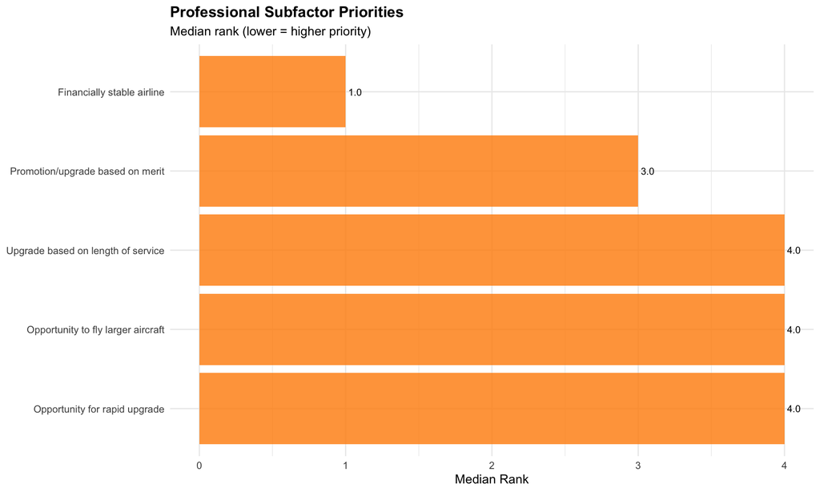

Median ranks for Professional Opportunity subfactors

Professional: Age Group Comparisons

| item | statistic | p | p_adj_holm | p.adj.signif | effsize | magnitude |
| --- | --- | --- | --- | --- | --- | --- |
| Financially stable airline | 180.0 | 0.095 | 0.475 | ns | 0.223 | small |
| Opportunity for rapid upgrade | 278.5 | 0.351 | 1.000 | ns | 0.125 | small |
| Opportunity to fly larger aircraft | 278.0 | 0.356 | 1.000 | ns | 0.124 | small |
| Promotion/upgrade based on merit | 206.0 | 0.537 | 1.000 | ns | 0.083 | small |
| Upgrade based on length of service | 182.5 | 0.251 | 1.000 | ns | 0.153 | small |

Median ranks for Professional Opportunity subfactors

Professional: Gender Comparisons

| item | statistic | p | p_adj_holm | p.adj.signif | effsize | magnitude |
| --- | --- | --- | --- | --- | --- | --- |
| Financially stable airline | 127.5 | 1.000 | 1.000 | ns | 0.000 | small |
| Opportunity for rapid upgrade | 134.5 | 0.847 | 1.000 | ns | 0.028 | small |
| Opportunity to fly larger aircraft | 197.0 | 0.040 | 0.161 | ns | 0.276 | small |
| Promotion/upgrade based on merit | 49.5 | 0.021 | 0.107 | ns | 0.309 | moderate |
| Upgrade based on length of service | 103.5 | 0.477 | 1.000 | ns | 0.097 | small |

Median ranks for Professional Opportunity subfactors

Professional: Position Comparisons

| item | statistic | p | p_adj_holm | p.adj.signif | effsize | magnitude |
| --- | --- | --- | --- | --- | --- | --- |
| Financially stable airline | 318.5 | 0.154 | 0.616 | ns | 0.190 | small |
| Opportunity for rapid upgrade | 395.5 | 0.771 | 1.000 | ns | 0.040 | small |
| Opportunity to fly larger aircraft | 401.5 | 0.694 | 1.000 | ns | 0.053 | small |
| Promotion/upgrade based on merit | 426.0 | 0.417 | 1.000 | ns | 0.109 | small |
| Upgrade based on length of service | 283.0 | 0.100 | 0.500 | ns | 0.219 | small |

Median ranks for Professional Opportunity subfactors

Professional: Military Comparisons

| item | statistic | p | p_adj_holm | p.adj.signif | effsize | magnitude |
| --- | --- | --- | --- | --- | --- | --- |
| Financially stable airline | 128.0 | 0.327 | 0.981 | ns | 0.133 | small |
| Opportunity for rapid upgrade | 151.0 | 0.151 | 0.604 | ns | 0.192 | small |
| Opportunity to fly larger aircraft | 57.0 | 0.117 | 0.585 | ns | 0.210 | small |
| Promotion/upgrade based on merit | 119.5 | 0.675 | 1.000 | ns | 0.058 | small |
| Upgrade based on length of service | 112.0 | 0.857 | 1.000 | ns | 0.026 | small |

Median ranks for Professional Opportunity subfactors

Professional: Experience Comparisons

| item | statistic | df | p | p_adj_holm | p.adj.signif | effsize | magnitude |
| --- | --- | --- | --- | --- | --- | --- | --- |
| Financially stable airline | 1.889 | 3 | 0.596 | 1.000 | ns | -0.021 | small |
| Opportunity for rapid upgrade | 5.492 | 3 | 0.139 | 0.695 | ns | 0.047 | small |
| Opportunity to fly larger aircraft | 0.768 | 3 | 0.857 | 1.000 | ns | -0.042 | small |
| Promotion/upgrade based on merit | 3.147 | 3 | 0.369 | 1.000 | ns | 0.003 | small |
| Upgrade based on length of service | 2.449 | 3 | 0.485 | 1.000 | ns | -0.010 | small |

Median ranks for Professional Opportunity subfactors

## 6.4 Recognition Subfactors

Recognition Subfactors - Descriptive Statistics

| item | n | median | mean | sd | pct_rank1 |
| --- | --- | --- | --- | --- | --- |
| Professional-looking uniforms | 57 | 3 | 2.63 | 0.99 | 19.30 |
| Additional vacation for long service | 57 | 2 | 2.11 | 1.03 | 35.09 |
| Recognition as a professional | 57 | 2 | 1.82 | 0.89 | 43.86 |
| Airline recognition | 57 | 4 | 3.44 | 0.85 | 1.75 |

Median ranks for Recognition subfactors

Recognition: Friedman Test

| .y. | n | statistic | df | p | method |
| --- | --- | --- | --- | --- | --- |
| rank | 57 | 51.653 | 3 | 0 | Friedman test |

Median ranks for Recognition subfactors

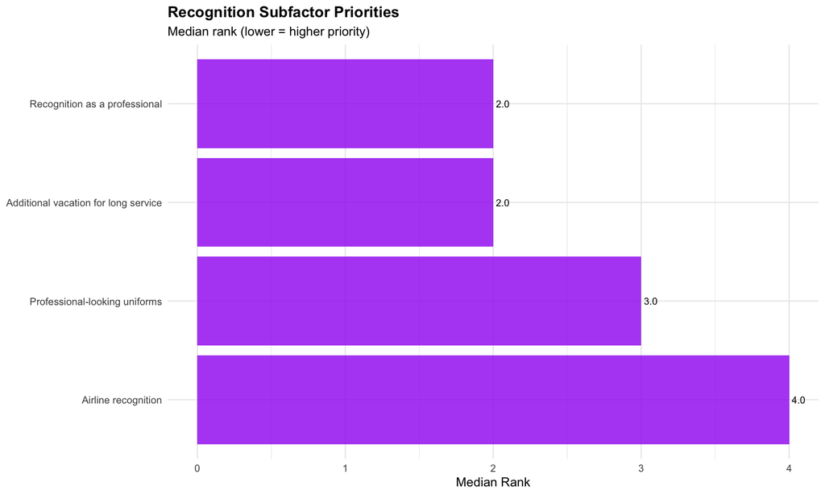

Median ranks for Recognition subfactors

Recognition: Age Group Comparisons

| item | statistic | p | p_adj_holm | p.adj.signif | effsize | magnitude |
| --- | --- | --- | --- | --- | --- | --- |
| Professional-looking uniforms | 248.0 | 0.779 | 1.000 | ns | 0.039 | small |
| Additional vacation for long service | 122.0 | 0.014 | 0.054 | ns | 0.328 | moderate |
| Recognition as a professional | 341.5 | 0.017 | 0.054 | ns | 0.318 | moderate |
| Airline recognition | 247.0 | 0.776 | 1.000 | ns | 0.039 | small |

Median ranks for Recognition subfactors

Recognition: Gender Comparisons

| item | statistic | p | p_adj_holm | p.adj.signif | effsize | magnitude |
| --- | --- | --- | --- | --- | --- | --- |
| Professional-looking uniforms | 73 | 0.097 | 0.387 | ns | 0.224 | small |
| Additional vacation for long service | 102 | 0.453 | 0.482 | ns | 0.102 | small |
| Recognition as a professional | 166 | 0.241 | 0.482 | ns | 0.159 | small |
| Airline recognition | 175 | 0.107 | 0.387 | ns | 0.217 | small |

Median ranks for Recognition subfactors

Recognition: Position Comparisons

| item | statistic | p | p_adj_holm | p.adj.signif | effsize | magnitude |
| --- | --- | --- | --- | --- | --- | --- |
| Professional-looking uniforms | 474.0 | 0.092 | 0.367 | ns | 0.225 | small |
| Additional vacation for long service | 292.5 | 0.141 | 0.423 | ns | 0.196 | small |
| Recognition as a professional | 427.5 | 0.384 | 0.592 | ns | 0.116 | small |
| Airline recognition | 324.0 | 0.296 | 0.592 | ns | 0.140 | small |

Median ranks for Recognition subfactors

Recognition: Military Comparisons

| item | statistic | p | p_adj_holm | p.adj.signif | effsize | magnitude |
| --- | --- | --- | --- | --- | --- | --- |
| Professional-looking uniforms | 67.5 | 0.205 | 0.540 | ns | 0.170 | small |
| Additional vacation for long service | 180.0 | 0.016 | 0.065 | ns | 0.320 | moderate |
| Recognition as a professional | 65.5 | 0.180 | 0.540 | ns | 0.180 | small |
| Airline recognition | 98.5 | 0.796 | 0.796 | ns | 0.037 | small |

Median ranks for Recognition subfactors

Recognition: Experience Comparisons

| item | statistic | df | p | p_adj_holm | p.adj.signif | effsize | magnitude |
| --- | --- | --- | --- | --- | --- | --- | --- |
| Professional-looking uniforms | 2.602 | 3 | 0.457 | 1.000 | ns | -0.008 | small |
| Additional vacation for long service | 5.950 | 3 | 0.114 | 0.456 | ns | 0.056 | small |
| Recognition as a professional | 3.095 | 3 | 0.377 | 1.000 | ns | 0.002 | small |
| Airline recognition | 0.814 | 3 | 0.846 | 1.000 | ns | -0.041 | small |

Median ranks for Recognition subfactors

## 6.5 Schedule Subfactors

Schedule Subfactors - Descriptive Statistics

| item | n | median | mean | sd | pct_rank1 |
| --- | --- | --- | --- | --- | --- |
| Fixed schedule | 57 | 3 | 3.02 | 1.67 | 29.82 |
| Variable schedule | 57 | 3 | 3.51 | 1.38 | 12.28 |
| Flexible work rules | 57 | 2 | 2.14 | 1.27 | 38.60 |
| Bid line seniority system | 57 | 3 | 2.77 | 1.21 | 19.30 |
| Vacation bidding rules | 57 | 4 | 3.56 | 1.00 | 0.00 |

Median ranks for Schedule subfactors

Schedule: Friedman Test

| .y. | n | statistic | df | p | method |
| --- | --- | --- | --- | --- | --- |
| rank | 57 | 31.13 | 4 | 0 | Friedman test |

Median ranks for Schedule subfactors

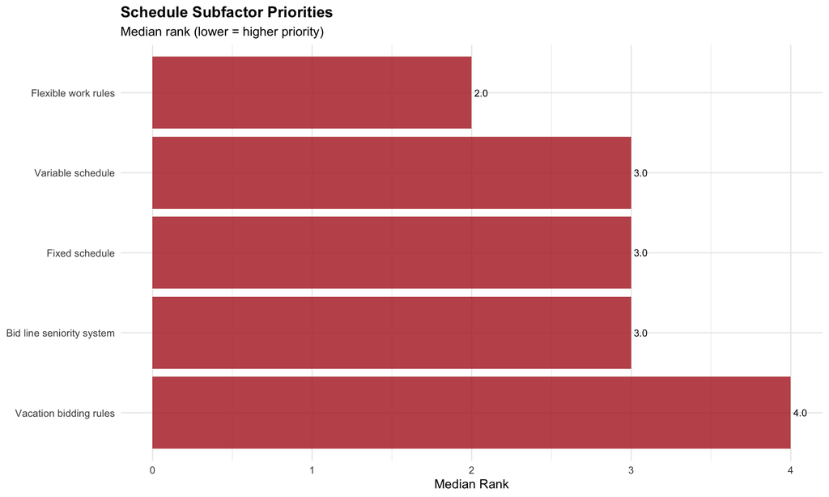

Median ranks for Schedule subfactors

Schedule: Age Group Comparisons

| item | statistic | p | p_adj_holm | p.adj.signif | effsize | magnitude |
| --- | --- | --- | --- | --- | --- | --- |
| Fixed schedule | 219.5 | 0.745 | 1 | ns | 0.045 | small |
| Variable schedule | 252.0 | 0.719 | 1 | ns | 0.049 | small |
| Flexible work rules | 279.0 | 0.335 | 1 | ns | 0.129 | small |
| Bid line seniority system | 238.0 | 0.957 | 1 | ns | 0.009 | small |
| Vacation bidding rules | 217.5 | 0.710 | 1 | ns | 0.051 | small |

Median ranks for Schedule subfactors

Schedule: Gender Comparisons

| item | statistic | p | p_adj_holm | p.adj.signif | effsize | magnitude |
| --- | --- | --- | --- | --- | --- | --- |
| Fixed schedule | 113.0 | 0.677 | 1 | ns | 0.058 | small |
| Variable schedule | 163.5 | 0.289 | 1 | ns | 0.144 | small |
| Flexible work rules | 102.0 | 0.447 | 1 | ns | 0.104 | small |
| Bid line seniority system | 135.0 | 0.836 | 1 | ns | 0.030 | small |
| Vacation bidding rules | 101.5 | 0.446 | 1 | ns | 0.104 | small |

Median ranks for Schedule subfactors

Schedule: Position Comparisons

| item | statistic | p | p_adj_holm | p.adj.signif | effsize | magnitude |
| --- | --- | --- | --- | --- | --- | --- |
| Fixed schedule | 412.5 | 0.561 | 1 | ns | 0.078 | small |
| Variable schedule | 379.0 | 0.993 | 1 | ns | 0.002 | small |
| Flexible work rules | 324.0 | 0.350 | 1 | ns | 0.125 | small |
| Bid line seniority system | 426.5 | 0.414 | 1 | ns | 0.109 | small |
| Vacation bidding rules | 332.0 | 0.433 | 1 | ns | 0.105 | small |

Median ranks for Schedule subfactors

Schedule: Military Comparisons

| item | statistic | p | p_adj_holm | p.adj.signif | effsize | magnitude |
| --- | --- | --- | --- | --- | --- | --- |
| Fixed schedule | 107.0 | 0.987 | 1 | ns | 0.004 | small |
| Variable schedule | 102.0 | 0.909 | 1 | ns | 0.017 | small |
| Flexible work rules | 113.0 | 0.830 | 1 | ns | 0.031 | small |
| Bid line seniority system | 76.5 | 0.351 | 1 | ns | 0.126 | small |
| Vacation bidding rules | 114.5 | 0.795 | 1 | ns | 0.037 | small |

Median ranks for Schedule subfactors

Schedule: Experience Comparisons

| item | statistic | df | p | p_adj_holm | p.adj.signif | effsize | magnitude |
| --- | --- | --- | --- | --- | --- | --- | --- |
| Fixed schedule | 2.894 | 3 | 0.408 | 1 | ns | -0.002 | small |
| Variable schedule | 3.805 | 3 | 0.283 | 1 | ns | 0.015 | small |
| Flexible work rules | 2.140 | 3 | 0.544 | 1 | ns | -0.016 | small |
| Bid line seniority system | 3.189 | 3 | 0.363 | 1 | ns | 0.004 | small |
| Vacation bidding rules | 1.678 | 3 | 0.642 | 1 | ns | -0.025 | small |

Median ranks for Schedule subfactors

## 6.6 Operational Subfactors

Operational Subfactors - Descriptive Statistics

| item | n | median | mean | sd | pct_rank1 |
| --- | --- | --- | --- | --- | --- |
| Unambiguous SOPs | 57 | 3 | 3.04 | 1.61 | 29.82 |
| Proactive training environment | 57 | 3 | 2.84 | 1.15 | 10.53 |
| Well-maintained aircraft | 57 | 2 | 2.25 | 1.20 | 38.60 |
| Well-equipped aircraft | 57 | 5 | 4.09 | 1.15 | 0.00 |
| Highly skilled fellow pilots | 57 | 3 | 2.79 | 1.28 | 21.05 |

Median ranks for Operational subfactors

Operational: Friedman Test

| .y. | n | statistic | df | p | method |
| --- | --- | --- | --- | --- | --- |
| rank | 57 | 41.558 | 4 | 0 | Friedman test |

Median ranks for Operational subfactors

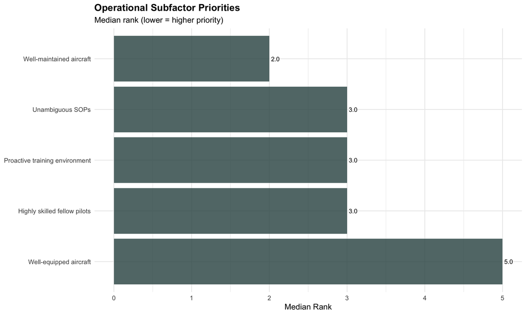

Median ranks for Operational subfactors

Operational: Age Group Comparisons

| item | statistic | p | p_adj_holm | p.adj.signif | effsize | magnitude |
| --- | --- | --- | --- | --- | --- | --- |
| Unambiguous SOPs | 262.5 | 0.560 | 1.00 | ns | 0.079 | small |
| Proactive training environment | 171.0 | 0.168 | 0.84 | ns | 0.184 | small |
| Well-maintained aircraft | 201.5 | 0.470 | 1.00 | ns | 0.097 | small |
| Well-equipped aircraft | 211.0 | 0.588 | 1.00 | ns | 0.073 | small |
| Highly skilled fellow pilots | 298.0 | 0.179 | 0.84 | ns | 0.180 | small |

Median ranks for Operational subfactors

Operational: Gender Comparisons

| item | statistic | p | p_adj_holm | p.adj.signif | effsize | magnitude |
| --- | --- | --- | --- | --- | --- | --- |
| Unambiguous SOPs | 134 | 0.859 | 1 | ns | 0.026 | small |
| Proactive training environment | 127 | 1.000 | 1 | ns | 0.002 | small |
| Well-maintained aircraft | 126 | 0.976 | 1 | ns | 0.006 | small |
| Well-equipped aircraft | 143 | 0.634 | 1 | ns | 0.066 | small |
| Highly skilled fellow pilots | 114 | 0.702 | 1 | ns | 0.053 | small |

Median ranks for Operational subfactors

Operational: Position Comparisons

| item | statistic | p | p_adj_holm | p.adj.signif | effsize | magnitude |
| --- | --- | --- | --- | --- | --- | --- |
| Unambiguous SOPs | 405.0 | 0.652 | 1 | ns | 0.061 | small |
| Proactive training environment | 424.5 | 0.431 | 1 | ns | 0.105 | small |
| Well-maintained aircraft | 321.5 | 0.334 | 1 | ns | 0.129 | small |
| Well-equipped aircraft | 366.0 | 0.834 | 1 | ns | 0.029 | small |
| Highly skilled fellow pilots | 355.5 | 0.709 | 1 | ns | 0.051 | small |

Median ranks for Operational subfactors

Operational: Military Comparisons

| item | statistic | p | p_adj_holm | p.adj.signif | effsize | magnitude |
| --- | --- | --- | --- | --- | --- | --- |
| Unambiguous SOPs | 132.0 | 0.412 | 1.000 | ns | 0.111 | small |
| Proactive training environment | 131.5 | 0.419 | 1.000 | ns | 0.109 | small |
| Well-maintained aircraft | 119.5 | 0.672 | 1.000 | ns | 0.058 | small |
| Well-equipped aircraft | 111.0 | 0.877 | 1.000 | ns | 0.023 | small |
| Highly skilled fellow pilots | 44.5 | 0.051 | 0.254 | ns | 0.261 | small |

Median ranks for Operational subfactors

Operational: Experience Comparisons

| item | statistic | df | p | p_adj_holm | p.adj.signif | effsize | magnitude |
| --- | --- | --- | --- | --- | --- | --- | --- |
| Unambiguous SOPs | 9.524 | 3 | 0.023 | 0.115 | ns | 0.123 | moderate |
| Proactive training environment | 2.568 | 3 | 0.463 | 1.000 | ns | -0.008 | small |
| Well-maintained aircraft | 2.298 | 3 | 0.513 | 1.000 | ns | -0.013 | small |
| Well-equipped aircraft | 8.314 | 3 | 0.040 | 0.160 | ns | 0.100 | moderate |
| Highly skilled fellow pilots | 3.031 | 3 | 0.387 | 1.000 | ns | 0.001 | small |

Median ranks for Operational subfactors

## 6.7 Hierarchical FDR Screening Results

Construct-Level Screening: Benjamini-Hochberg FDR (q=0.10)

| construct | n_subfactors | min_p | rank | p_adj_fdr | passes_screen | decision |
| --- | --- | --- | --- | --- | --- | --- |
| Financial | 6 | 0.0122 | 1 | 0.0293 | TRUE | Proceed to detailed testing |
| Recognition | 4 | 0.0136 | 2 | 0.0293 | TRUE | Proceed to detailed testing |
| Professional | 5 | 0.0215 | 3 | 0.0293 | TRUE | Proceed to detailed testing |
| Operational | 5 | 0.0231 | 4 | 0.0293 | TRUE | Proceed to detailed testing |
| Quality of Life | 6 | 0.0244 | 5 | 0.0293 | TRUE | Proceed to detailed testing |
| Schedule | 5 | 0.2830 | 6 | 0.2830 | FALSE | No demographic differences detected |

**Screening Summary:**

- Constructs passing FDR screen (p_adj < 0.10): 5 of 6

**Note**

For constructs passing screening, demographic comparisons have been adjusted using Holm’s procedure. Tests with p_adj_holm < 0.05 indicate significant demographic differences in subfactor prioritization.

# 7 Combined Results Summary

Combined Analysis Summary: Multiple Testing Approach

[output not shown]

## 7.1 Summary

**General Retention Factors (Part 1):**

- Total demographic comparisons: 24
- Significant at FDR q=0.10: 2

**Subfactor Analysis (Part 2):**

**TipInterpretation**

The hierarchical FDR procedure controls for the 155 subfactor tests by:

1. Screening at construct level (BH-FDR q=0.10 on 6 tests)
2. Applying Holm correction within constructs that pass screening

# 8 Limitations

**WarningStatistical Power Considerations**

With n = 57 (regional pilots only), this study has limited statistical power. Non-significant results should **not** be interpreted as evidence of no effect. Many analyses may be underpowered to detect small-to-medium effects.

This analysis has several important limitations:

## 8.1 Sample Size and Power

The sample of n = 57 provides adequate power only for detecting large effects. For demographic comparisons:

| Comparison | Group Sizes | Detectable Effect (80% power) |
| --- | --- | --- |
| Age groups | 47 vs 10 | Large (r > 0.50) |
| Experience | ~14 per quartile | Very large (eta-squared > 0.14) |
| Gender | 51 vs 5 | Very large only (r > 0.70) |
| Military | 53 vs 4 | Very large only (r > 0.70) |
| Position | 36 vs 21 | Medium-large (r > 0.40) |

**Gender and Military comparisons warrant particular caution**: With only 5 female and 4 military-background respondents in the regional subset, these analyses have very low power to detect even large effects.

## 8.2 Additional Limitations

1. **Multiple Testing Burden**: Despite FDR control, the large number of tests (155 in subfactor analysis) increases false discovery risk; the expected number of false discoveries at q=0.10 is approximately 10% of significant findings
2. **Self-Selection Bias**: Survey respondents may not represent all U.S. regional airline pilots; those with strong opinions about retention may be overrepresented
3. **Cross-Sectional Design**: Retention priorities may change over career stage; this snapshot cannot capture temporal dynamics
4. **Ranking Methodology**: Forced rankings prevent assessment of absolute importance; factors ranked low may still be important in absolute terms

# 9 References

## 9.1 Primary Sources

Hickey, M. J. (2025). *Rethinking pilot retention in the United States: An analysis of key factors* [Master’s thesis, University of North Dakota]. ProQuest Dissertations & Theses. https://www.proquest.com/docview/3246414757

Efthymiou, M., Njoya, E. T., Lo, P. L., Papatheodorou, A., & Randall, D. (2020). The factors influencing entry level airline pilot retention: An empirical study of Ryanair. *Journal of Air Transport Management*, 91, 101997. https://doi.org/10.1016/j.jairtraman.2020.101997

## 9.2 Statistical Methods

Benjamini, Y., & Hochberg, Y. (1995). Controlling the false discovery rate: A practical and powerful approach to multiple testing. *Journal of the Royal Statistical Society: Series B*, 57(1), 289-300.

Bender, R., & Lange, S. (1999). Multiple test procedures other than Bonferroni’s deserve wider use. *BMJ*, 318(7183), 600-601.

Armstrong, R. A. (2014). When to use the Bonferroni correction. *Ophthalmic and Physiological Optics*, 34(5), 502-508.

Li, J., & Ghosh, J. K. (2014). A two-step hierarchical hypothesis set testing framework. *BMC Bioinformatics*, 15, 108.